# nnet

### Introduction to Neural Networks

This notebook shows the important arguments you need to focus on when fitting Neural Networks. Although this is a regression example, the concepts apply Neural Networks for binary classification problems.

## Import Modules

```python
import numpy as np
import pandas as pd
import matplotlib.pyplot as plt

import seaborn as sns
```

## Read data

We will use the Mixed Input regression example from Week 06. This example consists of 1 numeric input and 1 categorical input. This simple example makes it easy to visualize model behavior via predictions and understand the complexity associated with the advanced methods.

```python
df = pd.read_csv('../week_06/week_06_example_A_2.csv')
```

```python
df.info()
```

```
<class 'pandas.core.frame.DataFrame'>
RangeIndex: 333 entries, 0 to 332
Data columns (total 3 columns):
 #   Column  Non-Null Count  Dtype
---  ------  --------------  -----
 0   x1      333 non-null    float64
 1   x2      333 non-null    object
 2   y       333 non-null    float64
dtypes: float64(2), object(1)
memory usage: 7.9+ KB
```

```python
df.nunique()
```

```
x1    333
x2      3
y     333
dtype: int64
```

```python
df.head()
```

|  | x1 | x2 | y |
| --- | --- | --- | --- |
| 0 | -0.809211 | A1 | -0.739259 |
| 1 | 0.575924 | A3 | 0.159402 |
| 2 | -1.431722 | A2 | 1.707754 |
| 3 | 0.547039 | A3 | -0.268798 |
| 4 | -1.565151 | A1 | -2.208507 |

As a reminder, this data set involves parabolic trends between the output and numeric input but the trend changes across the categories of the categorical input.

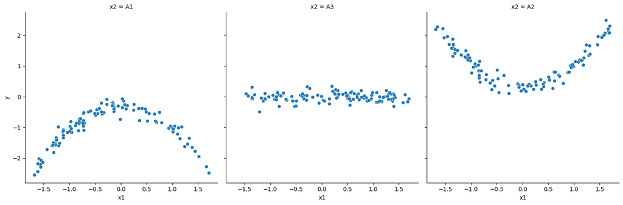

```python
sns.relplot(data = df, x='x1', y='y', col='x2', kind='scatter')

plt.show()
```

## Preprocessing

Inputs must be preprocessed before fitting advanced models. Most advanced models require the **same** type of preprocessing actions as **linear models**. Advanced therefore does **not** mean the models **automatically** handle any type of input! That said, **not** all models require the same level of preprocessing. Tree-based methods need the **least** amount of preprocessing, while neural networks can require the most!

That said, **all** `sklearn` models require DUMMY variables (or one hots) derived from categorical inputs. Thus, categorical inputs are the one type of input that **all** `sklearn` models require to be preprocessed. Elastic Net, Support Vector Machines, and Neural Networks require **all** numeric inputs to be **standardized** before fitting. You should consider removing skew for Elastic Net, SVM, and Neural Networks, but you do **not** need to worry about removing skew for tree based methods! You should also consider applying PCA if the numeric inputs are highly correlated as part of the preprocessing pipelines for SVM and Neural Networks.

Tree based methods do **not** need numeric inputs to be standardized. We will define a preprocessing Pipeline that standardizes the inputs and use that same pipeline for all advanced models. This way the various examples use the same basic preprocessing action. This is safe to do because the tree based methods do not care if the numeric inputs are standardized or not.

### Mixed Inputs

We need to create a **composite** Pipeline which allows generating the DUMMY variables and standardizing the continuous inputs!

Import the Pipeline module and the required preprocessing function from sklearn.

```python
from sklearn.pipeline import Pipeline
```

```python
from sklearn.preprocessing import StandardScaler
```

```python
from sklearn.preprocessing import OneHotEncoder
```

```python
from sklearn.compose import ColumnTransformer
```

Define lists which contain the names for the numeric inputs and the categorical inputs.

```python
names_numeric_inputs = ['x1']

names_cat_inputs = ['x2']
```

Extract the inputs from the entire data set.

```python
x_inputs_df = df.loc[:, names_numeric_inputs + names_cat_inputs].copy()
```

```python
x_inputs_df.head()
```

|  | x1 | x2 |
| --- | --- | --- |
| 0 | -0.809211 | A1 |
| 1 | 0.575924 | A3 |
| 2 | -1.431722 | A2 |
| 3 | 0.547039 | A3 |
| 4 | -1.565151 | A1 |

Define the transformations associated with each data type.

```python
numeric_transform = Pipeline( steps= [ ('std_input', StandardScaler() ) ] )
```

```python
categorical_transform = Pipeline( steps= [ ('dummy', OneHotEncoder(drop='first') ) ] )
```

Combine the two pipelines together via `ColumnTransformer()`.

```python
preprocess_transform = ColumnTransformer( transformers=[('num', numeric_transform, names_numeric_inputs),
                                                        ('cat', categorical_transform, names_cat_inputs)] )
```

```python
preprocess_transform
```

```
ColumnTransformer(transformers=[('num',
                                 Pipeline(steps=[('std_input',
                                                  StandardScaler())]),
                                 ['x1']),
                                ('cat',
                                 Pipeline(steps=[('dummy',
                                                  OneHotEncoder(drop='first'))]),
                                 ['x2'])])
```

```python
preprocess_transform.transformers
```

```
[('num', Pipeline(steps=[('std_input', StandardScaler())]), ['x1']),
 ('cat', Pipeline(steps=[('dummy', OneHotEncoder(drop='first'))]), ['x2'])]
```

If we wanted, we could execute the transformations to generate the FEATURES from the training data. This is accomplished by applying the `.fit_transform()` method to the training inputs. The first 6 rows of the preprocessed inputs are shown below. There are 3 columns because the 2 dummies are generated from the 1 categorical input because `x2` has 3 categories. The dummies are organized as the last two columns. The feature array or **DESIGN MATRIX** created below is equivalent to the **linear additive features** derived from **all inputs**. Advanced methods use the **linear additive features** and **generate further features** from these for us! Please note, that the design matrix below does **not** include the BIAS column (intercept feature column) because sklearn prefers the bias column to **not** be included.

```python
preprocess_transform.fit_transform( x_inputs_df )[:6, :]
```

```
array([[-0.84065964,  0.        ,  0.        ],
       [ 0.59508171,  0.        ,  1.        ],
       [-1.48591411,  1.        ,  0.        ],
       [ 0.56514161,  0.        ,  1.        ],
       [-1.62421867,  0.        ,  0.        ],
       [ 0.26367875,  1.        ,  0.        ]])
```

The cell below confirms the last 2 columns have exactly two unique values.

```python
pd.DataFrame( preprocess_transform.fit_transform( x_inputs_df ) ).nunique()
```

```
0    333
1      2
2      2
dtype: int64
```

For this example, the categories of `x2` are roughly balanced.

```python
df.x2.value_counts(normalize=True)
```

```
x2
A3    0.342342
A1    0.330330
A2    0.327327
Name: proportion, dtype: float64
```

As a reminder, a dummy value of 1 represents that the categorical input equals that category. The cell below confirms the first dummy column of the preprocessed features corresponds to the `x2=='A2'` category. We know this is the case because the 1 column in the preprocessed features equals 1 the same proportion of times `x2=='A2'`.

```python
pd.DataFrame( preprocess_transform.fit_transform( x_inputs_df ) ).iloc[:, 1].value_counts(normalize=True)
```

```
1
0.0    0.672673
1.0    0.327327
Name: proportion, dtype: float64
```

Likewise, the 2 column in the preprocessed features equals 1 the same proportion of times as `x2=='A3'`. The 2 column is therefore the DUMMY associated with the `x2=='A3'` category. A value of 1 in the 2 column of the preprocessed features means `x2` equals `'A3'`.

```python
pd.DataFrame( preprocess_transform.fit_transform( x_inputs_df ) ).iloc[:, 2].value_counts(normalize=True)
```

```
2
0.0    0.657658
1.0    0.342342
Name: proportion, dtype: float64
```

Please remember though, we will **NOT** generate the feature array before hand when using cross-validation to train and tune models! Instead, the preprocessing will be incorporated as a step of a modeling pipeline! This allows the preprocessing to be applied correctly **within** each resample fold!

## Neural networks

The Neural Network function for Regression applications is imported below. The MLP letters stand for Multi-Layer-Perceptron. This is due to Neural Networks being "modeled" after neurons in the brain. But, neural networks are NOT how the brain works. They are just mathematical models! In fact, they are just extensions of linear models!

```python
from sklearn.neural_network import MLPRegressor
```

### Small example - 2 hidden units

Let's create a very small neural network with 2 **HIDDEN UNITS**. The hidden units are what most people call **NEURONS**.

We will also use a HYPERBOLIC TANGENT **ACTIVATION FUNCTION**. The ACTIVATION FUNCTION converts our linear model into a NON-LINEAR relationship. The ACTIVATION FUNCTION is how the neural network **generates** FEATURES!!! The number of features is controlled by the number of hidden units. `sklearn` specifies by the number of hidden units (neurons) by the `hidden_layer_sizes` argument. The number of hidden units is an important **tuning** parameter for the neural network. More hidden units means more features. The more features we have the more coefficients that need to be estimated. Neural Networks do not refer to coefficients as coefficients. Instead, **intercepts** are named **biases** and coefficients or slopes are referred to as **weights**.

We also need to specify the **regularization strength** for restricting the coefficient or **WEIGHT** values! The neural network therefore borrows many ideas from Ridge regression! The regularization strength is named `alpha` in the `MLPRegressor()` function.

We also need to specify the **optimization** algorithm or `solver` and control how the optimization algorithm is executed. Popular choices are `'sgd'` and `'adam'`, however I prefer to `'lbfgs'` for most applications. That said, let's begin with `'sgd'` in this example. When setting `solver='sgd'` you should also specify the `max_iter`, `batch_size`, `learning_rate_init`, and `random_state`. The `batch_size` below is a small batch size. We will change this later.

#### Architecture overview

Define the neural network object that has 2 hidden units and a very small `alpha`.

```python
nnet_small_tanh_a0 = MLPRegressor(activation='tanh',
                                  hidden_layer_sizes=2,
                                  solver='sgd', max_iter=5001, batch_size=5, learning_rate_init=0.001, random_state=101,
                                  alpha=0.0001)
```

Combine the preprocessing transformation with the small network within a new Pipeline.

```python
nnet_small_tanh_a0_wflow = Pipeline( steps=[('prepro', preprocess_transform),
                                            ('nnet', nnet_small_tanh_a0)] )
```

```python
nnet_small_tanh_a0_wflow
```

```
Pipeline(steps=[('prepro',
                 ColumnTransformer(transformers=[('num',
                                                  Pipeline(steps=[('std_input',
                                                                   StandardScaler())]),
                                                  ['x1']),
                                                 ('cat',
                                                  Pipeline(steps=[('dummy',
                                                                   OneHotEncoder(drop='first'))]),
                                                  ['x2'])])),
                ('nnet',
                 MLPRegressor(activation='tanh', batch_size=5,
                              hidden_layer_sizes=2, max_iter=5001,
                              random_state=101, solver='sgd'))])
```

```python
nnet_small_tanh_a0_wflow.steps
```

```
[('prepro',
  ColumnTransformer(transformers=[('num',
                                   Pipeline(steps=[('std_input',
                                                    StandardScaler())]),
                                   ['x1']),
                                  ('cat',
                                   Pipeline(steps=[('dummy',
                                                    OneHotEncoder(drop='first'))]),
                                   ['x2'])])),
 ('nnet',
  MLPRegressor(activation='tanh', batch_size=5, hidden_layer_sizes=2,
               max_iter=5001, random_state=101, solver='sgd'))]
```

Let's fit or train the neural network using the training data.

```python
fit_nnet_small_tanh_a0 = nnet_small_tanh_a0_wflow.fit( x_inputs_df, df.y.to_numpy().ravel() )
```

The BIASES or **INTERCEPTS** are contained within the `.intercepts_` attribute of the FITTED neural network object.

```python
fit_nnet_small_tanh_a0
```

```
Pipeline(steps=[('prepro',
                 ColumnTransformer(transformers=[('num',
                                                  Pipeline(steps=[('std_input',
                                                                   StandardScaler())]),
                                                  ['x1']),
                                                 ('cat',
                                                  Pipeline(steps=[('dummy',
                                                                   OneHotEncoder(drop='first'))]),
                                                  ['x2'])])),
                ('nnet',
                 MLPRegressor(activation='tanh', batch_size=5,
                              hidden_layer_sizes=2, max_iter=5001,
                              random_state=101, solver='sgd'))])
```

We can access the underlying model via the `.named_steps[]` attribute!!!

```python
fit_nnet_small_tanh_a0.steps
```

```
[('prepro',
  ColumnTransformer(transformers=[('num',
                                   Pipeline(steps=[('std_input',
                                                    StandardScaler())]),
                                   ['x1']),
                                  ('cat',
                                   Pipeline(steps=[('dummy',
                                                    OneHotEncoder(drop='first'))]),
                                   ['x2'])])),
 ('nnet',
  MLPRegressor(activation='tanh', batch_size=5, hidden_layer_sizes=2,
               max_iter=5001, random_state=101, solver='sgd'))]
```

```python
fit_nnet_small_tanh_a0.named_steps['nnet']
```

```
MLPRegressor(activation='tanh', batch_size=5, hidden_layer_sizes=2,
             max_iter=5001, random_state=101, solver='sgd')
```

```python
fit_nnet_small_tanh_a0.named_steps['nnet'].intercepts_
```

```
[array([-0.46211728,  0.92066396]), array([0.68553192])]
```

There are 3 INTERCEPTS. The three are organized within a LIST. The "first" (0 element) contains the **HIDDEN UNIT** intercepts! These are the intercepts associated within each "neuron" which generate the features. The "second" (1 element) contains the **OUTPUT LAYER** intercept! These are the intercepts associated with the **features** that predict the response.

The regression coefficients or **WEIGHTS** are contained wiht the `.coefs_` attribute of the neural network object.

```python
fit_nnet_small_tanh_a0.named_steps['nnet'].coefs_
```

```
[array([[ 0.09069998, -0.013921  ],
        [-0.82928043, -1.84682699],
        [ 1.23324194,  0.17416217]]),
 array([[ 0.98574357],
        [-1.67441399]])]
```

The `.coefs_` are contained in a LIST. The "first" (0 element) is a NumPy 2D array. The "first" element contains the regression coefficients (slopes) for the **HIDDEN UNITS**. There are 2 columns because we have 2 hidden units. There are 3 rows because we have 3 columns in the DESIGN MATRIX (input feature array).

```python
fit_nnet_small_tanh_a0.named_steps['nnet'].coefs_[0].shape
```

```
(3, 2)
```

The "second" (1 element) is a NumPy array for the **OUTPUT LAYER** regression coefficients or WEIGHTS. There are 2 rows because we have 2 hidden units. There is 1 column because we are predicting 1 output.

```python
fit_nnet_small_tanh_a0.named_steps['nnet'].coefs_[1].shape
```

```
(2, 1)
```

Each hidden unit has a SLOPE or WEIGHT multiplying the input FEATURES.

The generated features are then MULTIPLIED by the OUTPUT LAYER weights!!!!

For our case, the hidden unit consists of the following formula:

$$ \eta_{n,1} = \beta_{0,1} + \beta_{1,1} x_{n,1} + \beta_{2B,1} x_{n,2B} + \beta_{2C,1} x_{n,2C} $$

Each hidden unit is a WEIGHTED SUM or LINEAR MODEL with LINEAR ADDITIVE FEATURES.

$$ \eta_{n,2} = \beta_{0,2} + \beta_{1,2} x_{n,1} + \beta_{2B,2} x_{n,2B} + \beta_{2C,2} x_{n,2C} $$

The ACTIVATION FUNCTION corresponds to NON-LINEAR transformations applied to the WEIGHTED SUM of the INPUTS!

$$ h_{n,1} = \mathrm{TANH}( \eta_{n,1} ) = \mathrm{TANH}( \beta_{0,1} + \beta_{1,1} x_{n,1} + \beta_{2B,1} x_{n,2B} + \beta_{2C,1} x_{n,2C} ) $$$$ h_{n,1} = \mathrm{TANH}( \eta_{n,1} ) = \mathrm{TANH}( \beta_{0,2} + \beta_{1,2} x_{n,1} + \beta_{2B,2} x_{n,2B} + \beta_{2C,2} x_{n,2C} )$$

The OUTPUT LAYER is a **LINEAR MODEL** relative to the transformed hidden units!!!

$$ \mathrm{TREND}_{n} = \alpha_{0} + \alpha_{1} h_{n,1} + \alpha_{2} h_{n,2} $$

The ENTIRE 2 hidden unit neural network is just:

$$ \mathrm{TREND}_{n} = \alpha_{0} + \alpha_{1} \mathrm{TANH}( \eta_{n,1} ) + \alpha_{2} \mathrm{TANH}( \eta_{n,2} ) $$

Include the HIDDEN UNIT weighted sums if the inputs:

$$ \mathrm{TREND}_{n} = \alpha_{0} + \alpha_{1} \mathrm{TANH}( \beta_{0,1} + \beta_{1,1} x_{n,1} + \beta_{2,1} x_{n,2} + \beta_{3,1} x_{n,3} ) + \alpha_{2} \mathrm{TANH}( \beta_{0,2} + \beta_{1,2} x_{n,1} + \beta_{2,2} x_{n,2} + \beta_{3,2} x_{n,3} ) $$

#### The importance of the random seed

Let's refit the same model, but this time with a different random state. All other arguments to `MLPRegressor()` are the same.

```python
nnet_small_tanh_a1 = MLPRegressor(activation='tanh', hidden_layer_sizes=2,
                                  solver='sgd', max_iter=5001, batch_size=5, learning_rate_init=0.001, random_state=7827934,
                                  alpha=0.0001)
```

```python
nnet_small_tanh_a1_wflow = Pipeline( steps=[('prepro', preprocess_transform),
                                            ('nnet', nnet_small_tanh_a1)] )
```

Fit the "new" model. Remember that the only difference with the previous model is the `random_state`.

```python
fit_nnet_small_tanh_a1 = nnet_small_tanh_a1_wflow.fit( x_inputs_df, df.y.to_numpy().ravel() )
```

The INTERCEPTS for the new fit.

```python
fit_nnet_small_tanh_a1.named_steps['nnet'].intercepts_
```

```
[array([-0.43334451,  0.49606593]), array([-0.11907231])]
```

The INTERCEPTS for the previous fit.

```python
fit_nnet_small_tanh_a0.named_steps['nnet'].intercepts_
```

```
[array([-0.46211728,  0.92066396]), array([0.68553192])]
```

The regression coefficients for the new fit:

```python
fit_nnet_small_tanh_a1.named_steps['nnet'].coefs_
```

```
[array([[ 0.45148023, -0.01312082],
        [-0.50825204, -1.34547759],
        [ 0.33717747, -0.55254667]]),
 array([[ 0.10079138],
        [-1.79008076]])]
```

The regression coefficients for the previous fit:

```python
fit_nnet_small_tanh_a0.named_steps['nnet'].coefs_
```

```
[array([[ 0.09069998, -0.013921  ],
        [-0.82928043, -1.84682699],
        [ 1.23324194,  0.17416217]]),
 array([[ 0.98574357],
        [-1.67441399]])]
```

Changing the random seed therefore **changed** the optimized coefficient estimates! We never saw anything like this with linear models, logistic regression, or Poisson regression. Fitting the model multiple times always produced the same coefficients. However, changing the random seed changes the coefficients!

What if we **do not** set the `random_state` argument and thus do **not** set the random seed?

```python
nnet_small_tanh_a1b = MLPRegressor(activation='tanh', hidden_layer_sizes=2,
                                   solver='sgd', max_iter=5001, batch_size=5, learning_rate_init=0.001,
                                   alpha=0.0001)
```

```python
nnet_small_tanh_a1b_wflow = Pipeline( steps=[('prepro', preprocess_transform),
                                             ('nnet', nnet_small_tanh_a1b)] )
```

Fit the model that did NOT set the random seed.

```python
fit_nnet_small_tanh_a1b = nnet_small_tanh_a1b_wflow.fit( x_inputs_df, df.y.to_numpy().ravel() )
```

The intercepts or **BIASES** for this new model are:

```python
fit_nnet_small_tanh_a1b.named_steps['nnet'].intercepts_
```

```
[array([-0.00637588,  1.46025425]), array([-1.58276905])]
```

The coefficients or **WEIGHTS** for this new model are:

```python
fit_nnet_small_tanh_a1b.named_steps['nnet'].coefs_
```

```
[array([[ 0.20053768, -1.09917139],
        [ 1.65167204,  1.90052824],
        [ 0.50436777,  0.2322628 ]]),
 array([[1.89097371],
        [0.8884628 ]])]
```

Again, we get different estimates!

**Why does this matter?**

It seems like the random seed is controlling the coefficients. But do **not** think using a default value means we use a default seed! Let's see what happens if we re-initialize without setting the random seed.

```python
nnet_small_tanh_a1c = MLPRegressor(activation='tanh', hidden_layer_sizes=2,
                                   solver='sgd', max_iter=5001, batch_size=5, learning_rate_init=0.001,
                                   alpha=0.0001)
```

```python
nnet_small_tanh_a1c_wflow = Pipeline( steps=[('prepro', preprocess_transform),
                                             ('nnet', nnet_small_tanh_a1c)] )
```

```python
fit_nnet_small_tanh_a1c = nnet_small_tanh_a1c_wflow.fit( x_inputs_df, df.y.to_numpy().ravel() )
```

The intercepts for the second fit without setting the random seed are:

```python
fit_nnet_small_tanh_a1c.named_steps['nnet'].intercepts_
```

```
[array([-0.12092504,  0.77234521]), array([-0.56142458])]
```

Are these the same intercepts as the last fit? **NO!**

```python
fit_nnet_small_tanh_a1b.named_steps['nnet'].intercepts_
```

```
[array([-0.00637588,  1.46025425]), array([-1.58276905])]
```

The coefficients for the second fit without setting the random seed are:

```python
fit_nnet_small_tanh_a1c.named_steps['nnet'].coefs_
```

```
[array([[ 0.0036097 , -0.46312403],
        [ 1.48250884,  0.05048923],
        [ 0.46103909, -0.12214583]]),
 array([[ 2.05886554],
        [-0.33342947]])]
```

Are these the same coefficients as the last fit? **NO!**

```python
fit_nnet_small_tanh_a1b.named_steps['nnet'].coefs_
```

```
[array([[ 0.20053768, -1.09917139],
        [ 1.65167204,  1.90052824],
        [ 0.50436777,  0.2322628 ]]),
 array([[1.89097371],
        [0.8884628 ]])]
```

**So...why does this matter?**

If you **do not** set the random seed **you may NEVER reproduce** the training results! The reason is because the default random seed is based on the timestamp (clock time) that the model is fit. If you do **not** set the random seed you will **always** use a **different** random seed.

Thus, although it seemed like changing the random seed changed the coefficients...at least by setting the random seed we can **reproduce** the results! Let's show this is in fact true by re-initializing the object with the `random_state=101`.

```python
nnet_small_tanh_a0_again = MLPRegressor(activation='tanh',
                                        hidden_layer_sizes=2,
                                        solver='sgd', max_iter=5001, batch_size=5, learning_rate_init=0.001, random_state=101,
                                        alpha=0.0001)
```

```python
nnet_small_tanh_a0_again_wflow = Pipeline( steps=[('prepro', preprocess_transform),
                                                  ('nnet', nnet_small_tanh_a0_again)] )
```

```python
fit_nnet_small_tanh_a0_again = nnet_small_tanh_a0_again_wflow.fit( x_inputs_df, df.y.to_numpy().ravel() )
```

The intercepts for the second time fitting the model with `random_state=101` are:

```python
fit_nnet_small_tanh_a0_again.named_steps['nnet'].intercepts_
```

```
[array([-0.46211728,  0.92066396]), array([0.68553192])]
```

How do they compare to the first time we fit the model with `random_state=101`? They are the **same**!

```python
fit_nnet_small_tanh_a0.named_steps['nnet'].intercepts_
```

```
[array([-0.46211728,  0.92066396]), array([0.68553192])]
```

What about the coefficients? They are the **same** as the coefficients for the first time we fit the model with `random_state=101`.

```python
fit_nnet_small_tanh_a0_again.named_steps['nnet'].coefs_
```

```
[array([[ 0.09069998, -0.013921  ],
        [-0.82928043, -1.84682699],
        [ 1.23324194,  0.17416217]]),
 array([[ 0.98574357],
        [-1.67441399]])]
```

```python
fit_nnet_small_tanh_a0.named_steps['nnet'].coefs_
```

```
[array([[ 0.09069998, -0.013921  ],
        [-0.82928043, -1.84682699],
        [ 1.23324194,  0.17416217]]),
 array([[ 0.98574357],
        [-1.67441399]])]
```

This shows, the only way to **reproduce** the intercepts and coefficients (biases and weights) of a Neural Network is to **set the random seed**. If you do not you **may NEVER** be able to reproduce the results!

#### Fitting and batch size

The `'sgd'` algorithm has **a lot** of randomness involved to it. The **s** stands for **stochastic**. The first level of randomness is the **initial guess** is randomly set. Then at each iteration a random subset of training points are selected in the fitting algorithm. The number of randomly selected training points is controlled by `batch_size`. With `batch_size=5` we are randomly selecting 5 points at each iteration. This leads to question of what happens if we raise the `batch_size` to randomly select more data point at each iteration? Let's increase `batch_size` to a recommended value of 30. Let's continue to use the `random_state=101`.

```python
nnet_small_tanh_a2 = MLPRegressor(activation='tanh',
                                  hidden_layer_sizes=2,
                                  solver='sgd', max_iter=5001, batch_size=30, learning_rate_init=0.001, random_state=101,
                                  alpha=0.0001)
```

```python
nnet_small_tanh_a2_wflow = Pipeline( steps=[('prepro', preprocess_transform),
                                            ('nnet', nnet_small_tanh_a2)] )
```

```python
fit_nnet_small_tanh_a2 = nnet_small_tanh_a2_wflow.fit( x_inputs_df, df.y.to_numpy().ravel() )
```

The intercepts with the larger batch size are:

```python
fit_nnet_small_tanh_a2.named_steps['nnet'].intercepts_
```

```
[array([-0.4814306 ,  0.90880495]), array([0.69132531])]
```

These are rather similar to the first time we used `random_state=101`.

```python
fit_nnet_small_tanh_a0.named_steps['nnet'].intercepts_
```

```
[array([-0.46211728,  0.92066396]), array([0.68553192])]
```

How do the coefficients compare to the original attempt?

```python
fit_nnet_small_tanh_a2.named_steps['nnet'].coefs_
```

```
[array([[ 0.10315222, -0.02239691],
        [-0.84574167, -1.82066928],
        [ 1.19751503,  0.19429713]]),
 array([[ 0.96045313],
        [-1.64128247]])]
```

They also seem rather close to the original coefficients!

```python
fit_nnet_small_tanh_a0.named_steps['nnet'].coefs_
```

```
[array([[ 0.09069998, -0.013921  ],
        [-0.82928043, -1.84682699],
        [ 1.23324194,  0.17416217]]),
 array([[ 0.98574357],
        [-1.67441399]])]
```

But, does increasing `batch_size` cause other random seeds to produce similar estimates? Let's find out! The cell below uses the second random seed, `random_state=7827934` with `batch_size=30`.

```python
nnet_small_tanh_a2b = MLPRegressor(activation='tanh',
                                   hidden_layer_sizes=2,
                                   solver='sgd', max_iter=5001, batch_size=30, learning_rate_init=0.001, random_state=7827934,
                                   alpha=0.0001)
```

```python
nnet_small_tanh_a2b_wflow = Pipeline( steps=[('prepro', preprocess_transform),
                                             ('nnet', nnet_small_tanh_a2b)] )
```

```python
fit_nnet_small_tanh_a2b = nnet_small_tanh_a2b_wflow.fit( x_inputs_df, df.y.to_numpy().ravel() )
```

The intercepts for this new fit are:

```python
fit_nnet_small_tanh_a2b.named_steps['nnet'].intercepts_
```

```
[array([-0.45034395,  0.48383706]), array([-0.11545011])]
```

They are different from the intercepts for the `random_state=101` and `batch_size=30`.

```python
fit_nnet_small_tanh_a2.named_steps['nnet'].intercepts_
```

```
[array([-0.4814306 ,  0.90880495]), array([0.69132531])]
```

But they are similar to the intercepts in the original fit with `random_state=7827934`.

```python
fit_nnet_small_tanh_a1.named_steps['nnet'].intercepts_
```

```
[array([-0.43334451,  0.49606593]), array([-0.11907231])]
```

**Why does this matter?**

The `batch_size` impacts how many training points are used at each iteration of the fitting algorithm. It is recommended to use `batch_size` between 30 to 50 in modern applications. But, these recommended values **do not** cause different random seeds to yield the same coefficients! This shows that the `batch_size` cannot overcome the randomness of the **initial guess**! Again, if you do **not** set the random seed you may **never be able to reproduce** the results!

#### Impact of learning rate

The `learning_rate_init` or **learning rate** is how "quickly" the fitting algorithm is allowed to finish. Larger values can allow the algorithm to need fewer total iterations. Let's raise the learning rate to 0.1 and continue to use the `batch_size=30` and the `random_state=101`.

Next, let's try a different LEARNING RATE:

```python
nnet_small_tanh_a3 = MLPRegressor(activation='tanh',
                                  hidden_layer_sizes=2,
                                  solver='sgd', max_iter=5001, batch_size=30, learning_rate_init=0.1, random_state=101,
                                  alpha=0.0001)
```

```python
nnet_small_tanh_a3_wflow = Pipeline( steps=[('prepro', preprocess_transform),
                                            ('nnet', nnet_small_tanh_a3)] )
```

```python
fit_nnet_small_tanh_a3 = nnet_small_tanh_a3_wflow.fit( x_inputs_df, df.y.to_numpy().ravel() )
```

The newest set of intercepts:

```python
fit_nnet_small_tanh_a3.named_steps['nnet'].intercepts_
```

```
[array([2.4760268 , 1.60829812]), array([0.88101563])]
```

Which are different from the original intercepts associated with `random_state=101`.

```python
fit_nnet_small_tanh_a0.named_steps['nnet'].intercepts_
```

```
[array([-0.46211728,  0.92066396]), array([0.68553192])]
```

Changing the learning rate therefore does **not** ensure you will reach the same estimates faster! This is because **SGD** is **randomly** picking the data points during the fitting algorithm! It is recommended to use a "small" value and the default value is `learning_rate_init=0.001`. Using a value smaller than this may cause the algorithm to run for a very long time.

#### ADAM optimizer

The SGD algorithm uses a **constant** learning rate. The `solver='adam'` adapts the learning rate which can alleviate concerns over which value be used. The `solver='adam'` is the default `solver` value. The cell below uses the `random_state=101` with `solver='adam'`.

```python
nnet_small_tanh_a4 = MLPRegressor(activation='tanh',
                                  hidden_layer_sizes=2,
                                  solver='adam', max_iter=5001, batch_size=30, learning_rate_init=0.1, random_state=101,
                                  alpha=0.0001)
```

```python
nnet_small_tanh_a4_wflow = Pipeline( steps=[('prepro', preprocess_transform),
                                            ('nnet', nnet_small_tanh_a4)] )
```

```python
fit_nnet_small_tanh_a4 = nnet_small_tanh_a4_wflow.fit( x_inputs_df, df.y.to_numpy().ravel() )
```

The intercepts found by the ADAM optimizer are different from the intercepts found by SGD!

```python
fit_nnet_small_tanh_a4.named_steps['nnet'].intercepts_
```

```
[array([3.16052149, 1.32839164]), array([0.53557633])]
```

```python
fit_nnet_small_tanh_a0.named_steps['nnet'].intercepts_
```

```
[array([-0.46211728,  0.92066396]), array([0.68553192])]
```

#### LBFGS optimizer

The `sklearn` documentation states that the ADAM optimizer is "good" for most problems. The ADAM optimizer is relatively new and is quite popular in Deep Learning applications. However, the `sklearn` documentation also states that the LBFGS optimizer can work "better" for "small problems". The LBFGS algorithm is older and is based on classic Newton methods and is a popular strategy for fitting classic Generalized Linear Models. LBFGS does not require the user to specify a learning rate because it automatically adapts the learning rate for the user. Unfortunately, LBFGS has fallen out of favor recently simply because it is not used in Deep Learning. This is what the documentation means when it says "it does well on small problems". The documentation does not state what a "small" problem is, but I feel if there are less than 5000 unknown parameters, LBFGS will be a good strategy to use.

The slides on Neural Networks show how to determine the number of unknown parameters being estimated in more detail. But it depends on the number of columns in the DESIGN MATRIX and the number of HIDDEN UNITS. The formula for the number of unknown parameters in a SINGLE HIDDEN LAYER feedforward Neural Network is given below. The formula below assumes the design matrix

$$\left(\mathrm{number\ of\ hidden\ units}\right) \times \left(\mathrm{number\ of\ columns\ in\ design\ matrix + 1}\right) + \left(\mathrm{number\ of\ hidden\ units}\right) + 1 $$

You can therefore calculate the number of unknown parameters **before** fitting the model! In our current case with 3 columns in the design matrix and 2 hidden units there are:

$$ 2 \times \left(3+1\right) + 2 + 1 = 11 $$

Let's confirm this is the case by checking the number of coefficients estimated in one of the models. There are 3 intercepts or **biases** estimated.

```python
fit_nnet_small_tanh_a4.named_steps['nnet'].intercepts_
```

```
[array([3.16052149, 1.32839164]), array([0.53557633])]
```

There are 8 total coefficients or **weights** estimated.

```python
fit_nnet_small_tanh_a4.named_steps['nnet'].coefs_
```

```
[array([[ 2.23819146,  0.13501338],
        [-5.72297689, -1.98140132],
        [ 0.59933052, -0.76848444]]),
 array([[ 1.12617428],
        [-2.53359582]])]
```

Thus, 3 intercepts and 8 coefficients equals 11 total parameters! The number of coefficients is the same as what the formula provided previously calculated. Please note that formula only works if the bias column is **not** included in the design matrix. If the bias column (intercept column of 1s) **is** included, then the number of unknown parameters is equal to:

$$\left(\mathrm{number\ of\ hidden\ units}\right) \times \left(\mathrm{number\ of\ columns\ in\ design\ matrix}\right) + \left(\mathrm{number\ of\ hidden\ units}\right) + 1 $$

Lastly, please note this formula only holds for a SINGLE HIDDEN LAYER neural network. The number of unknown parameters for multiple hidden layers can be calculated but the formula is more complex.

What this means is that our current example is clearly a "small" example. We have just 11 parameters and a few hundred observations. Let's use `solver='lbfgs'` as the optimization algorithm! The random seed is set to `random_state=101`.

```python
nnet_small_tanh_a5 = MLPRegressor(activation='tanh',
                                  hidden_layer_sizes=2,
                                  solver='lbfgs', max_iter=5001, random_state=101,
                                  alpha=0.0001)
```

```python
nnet_small_tanh_a5_wflow = Pipeline( steps=[('prepro', preprocess_transform),
                                            ('nnet', nnet_small_tanh_a5)] )
```

```python
fit_nnet_small_tanh_a5 = nnet_small_tanh_a5_wflow.fit( x_inputs_df, df.y.to_numpy().ravel() )
```

The intercpets estimated by LBFGS are:

```python
fit_nnet_small_tanh_a5.named_steps['nnet'].intercepts_
```

```
[array([1.32536692, 1.01310166]), array([22.22390914])]
```

These are clearly different than what we saw from SGD or ADAM!

```python
fit_nnet_small_tanh_a0.named_steps['nnet'].intercepts_
```

```
[array([-0.46211728,  0.92066396]), array([0.68553192])]
```

```python
fit_nnet_small_tanh_a4.named_steps['nnet'].intercepts_
```

```
[array([3.16052149, 1.32839164]), array([0.53557633])]
```

Unfortunately, changing the random seed still yields different estimates even with LBFGS!

```python
nnet_small_tanh_a6 = MLPRegressor(activation='tanh',
                                  hidden_layer_sizes=2,
                                  solver='lbfgs', max_iter=5001, random_state=7827934,
                                  alpha=0.0001)
```

```python
nnet_small_tanh_a6_wflow = Pipeline( steps=[('prepro', preprocess_transform),
                                            ('nnet', nnet_small_tanh_a6)] )
```

```python
fit_nnet_small_tanh_a6 = nnet_small_tanh_a6_wflow.fit( x_inputs_df, df.y.to_numpy().ravel() )
```

The intercepts are **not** the same as what we got with the previous random seed!

```python
fit_nnet_small_tanh_a6.named_steps['nnet'].intercepts_
```

```
[array([1.32258081, 1.05257299]), array([25.80492194])]
```

```python
fit_nnet_small_tanh_a5.named_steps['nnet'].intercepts_
```

```
[array([1.32536692, 1.01310166]), array([22.22390914])]
```

Though the results are closer compared to what we saw with changing the seeds with the SGD or ADAM optimizers. But this was purely luck. Changing the random seed again can yield completely different results.

```python
nnet_small_tanh_a7 = MLPRegressor(activation='tanh',
                                  hidden_layer_sizes=2,
                                  solver='lbfgs', max_iter=5001, random_state=909,
                                  alpha=0.0001)
```

```python
nnet_small_tanh_a7_wflow = Pipeline( steps=[('prepro', preprocess_transform),
                                            ('nnet', nnet_small_tanh_a7)] )
```

```python
fit_nnet_small_tanh_a7 = nnet_small_tanh_a7_wflow.fit( x_inputs_df, df.y.to_numpy().ravel() )
```

The intercepts with this new random seed are completely different from the intercepts from our previous LBFGS attemps!

```python
fit_nnet_small_tanh_a7.named_steps['nnet'].intercepts_
```

```
[array([0.21745101, 0.34033177]), array([-0.85289164])]
```

```python
fit_nnet_small_tanh_a6.named_steps['nnet'].intercepts_
```

```
[array([1.32258081, 1.05257299]), array([25.80492194])]
```

#### Study trends via predictions

We have fit the neural network with same architecture - same number of hidden units and activation functions - but with different optimizer settings and algorithms. We have seen the intercept and coefficient estimates are different because of these settings. But, how do those different estimates "translate" to predictons of the response? Let's find out! The cell below creates a visualization grid for the inputs. The inputs values are defined using their **raw** training set scales. This is safe to do because the Pipeline will apply the preprocessing actions we need!

```python
viz_grid = pd.DataFrame([ (xa, xb) for xa in np.linspace(df.x1.min(), df.x1.max(), num=151)
                                   for xb in df.x2.unique() ],
                        columns=x_inputs_df.columns)
```

```python
viz_grid
```

|  | x1 | x2 |
| --- | --- | --- |
| 0 | -1.690977 | A1 |
| 1 | -1.690977 | A3 |
| 2 | -1.690977 | A2 |
| 3 | -1.668311 | A1 |
| 4 | -1.668311 | A3 |
| ... | ... | ... |
| 448 | 1.686251 | A3 |
| 449 | 1.686251 | A2 |
| 450 | 1.708917 | A1 |
| 451 | 1.708917 | A3 |
| 452 | 1.708917 | A2 |

453 rows × 2 columns

```python
viz_grid.nunique()
```

```
x1    151
x2      3
dtype: int64
```

The Pipelines fitted objects are complete models! We can call the predict method associated with the model!

```python
fit_nnet_small_tanh_a0.predict( viz_grid )[:11]
```

```
array([-1.09357316, -0.1284958 ,  1.00329585, -1.09186117, -0.12683132,
        1.00397751, -1.09014563, -0.12517016,  1.00466064, -1.08842654,
       -0.12351234])
```

```python
viz_grid_copy = viz_grid.copy()
```

```python
viz_grid_copy['pred_tanh_a0'] = fit_nnet_small_tanh_a0.predict( viz_grid )
viz_grid_copy['pred_tanh_a1'] = fit_nnet_small_tanh_a1.predict( viz_grid )
viz_grid_copy['pred_tanh_a1b'] = fit_nnet_small_tanh_a1b.predict( viz_grid )
viz_grid_copy['pred_tanh_a1c'] = fit_nnet_small_tanh_a1c.predict( viz_grid )
viz_grid_copy['pred_tanh_a2'] = fit_nnet_small_tanh_a2.predict( viz_grid )
viz_grid_copy['pred_tanh_a2b'] = fit_nnet_small_tanh_a2b.predict( viz_grid )
viz_grid_copy['pred_tanh_a3'] = fit_nnet_small_tanh_a3.predict( viz_grid )
viz_grid_copy['pred_tanh_a4'] = fit_nnet_small_tanh_a4.predict( viz_grid )
viz_grid_copy['pred_tanh_a5'] = fit_nnet_small_tanh_a5.predict( viz_grid )
viz_grid_copy['pred_tanh_a6'] = fit_nnet_small_tanh_a6.predict( viz_grid )
viz_grid_copy['pred_tanh_a7'] = fit_nnet_small_tanh_a7.predict( viz_grid )
```

```python
viz_grid_copy
```

|  | x1 | x2 | pred_tanh_a0 | pred_tanh_a1 | pred_tanh_a1b | pred_tanh_a1c | pred_tanh_a2 | pred_tanh_a2b | pred_tanh_a3 | pred_tanh_a4 | pred_tanh_a5 | pred_tanh_a6 | pred_tanh_a7 |
| --- | --- | --- | --- | --- | --- | --- | --- | --- | --- | --- | --- | --- | --- |
| 0 | -1.690977 | A1 | -1.093573 | -1.057727 | -1.346197 | -1.128574 | -1.078496 | -1.025688 | -2.497756 | -2.211159 | -2.181540 | -2.161340 | -2.301675 |
| 1 | -1.690977 | A3 | -0.128496 | -0.130822 | -0.421217 | -0.198134 | -0.176769 | -0.137894 | -1.133691 | -0.442220 | -1.074651 | -1.054225 | -0.948304 |
| 2 | -1.690977 | A2 | 1.003296 | 1.000862 | 0.931925 | 0.931639 | 0.973855 | 1.003402 | 1.217025 | 1.211678 | 2.151652 | 2.187669 | 1.386045 |
| 3 | -1.668311 | A1 | -1.091861 | -1.056986 | -1.338435 | -1.127835 | -1.076557 | -1.024783 | -2.457430 | -2.178316 | -2.134218 | -2.114772 | -2.256361 |
| 4 | -1.668311 | A3 | -0.126831 | -0.129737 | -0.412569 | -0.197269 | -0.174711 | -0.136637 | -1.087768 | -0.391422 | -1.030497 | -1.010883 | -0.904318 |
| ... | ... | ... | ... | ... | ... | ... | ... | ... | ... | ... | ... | ... | ... |
| 448 | 1.686251 | A3 | 0.083260 | 0.083151 | -0.475785 | 0.176955 | 0.085507 | 0.085478 | -0.463766 | -0.014453 | -0.589287 | -0.581911 | -0.288394 |
| 449 | 1.686251 | A2 | 1.124111 | 1.123217 | 1.033882 | 1.241946 | 1.121757 | 1.126291 | 1.809997 | 2.518526 | 2.277306 | 2.288091 | 2.102708 |
| 450 | 1.708917 | A1 | -0.799228 | -0.872315 | -1.349065 | -0.780511 | -0.737969 | -0.836961 | -0.767730 | -0.660530 | -1.328034 | -1.320865 | -1.229226 |
| 451 | 1.708917 | A3 | 0.084445 | 0.084380 | -0.492809 | 0.180643 | 0.086974 | 0.086852 | -0.467249 | -0.018963 | -0.605890 | -0.598562 | -0.275779 |
| 452 | 1.708917 | A2 | 1.125075 | 1.124543 | 1.029801 | 1.245613 | 1.122924 | 1.127443 | 1.820257 | 2.525193 | 2.325540 | 2.337212 | 2.140687 |

453 rows × 13 columns

```python
viz_grid_copy.melt(id_vars=['x1', 'x2'])
```

|  | x1 | x2 | variable | value |
| --- | --- | --- | --- | --- |
| 0 | -1.690977 | A1 | pred_tanh_a0 | -1.093573 |
| 1 | -1.690977 | A3 | pred_tanh_a0 | -0.128496 |
| 2 | -1.690977 | A2 | pred_tanh_a0 | 1.003296 |
| 3 | -1.668311 | A1 | pred_tanh_a0 | -1.091861 |
| 4 | -1.668311 | A3 | pred_tanh_a0 | -0.126831 |
| ... | ... | ... | ... | ... |
| 4978 | 1.686251 | A3 | pred_tanh_a7 | -0.288394 |
| 4979 | 1.686251 | A2 | pred_tanh_a7 | 2.102708 |
| 4980 | 1.708917 | A1 | pred_tanh_a7 | -1.229226 |
| 4981 | 1.708917 | A3 | pred_tanh_a7 | -0.275779 |
| 4982 | 1.708917 | A2 | pred_tanh_a7 | 2.140687 |

4983 rows × 4 columns

Some of the neural networks produce essentially linear trends! Others are yielding behavior that is roughly parabolic. If you look closely, you'll notice that some of the SGD results are the linear trends. The SGD results therefore do not seem to capture the trends in the data. This is due to not using enough iterations!

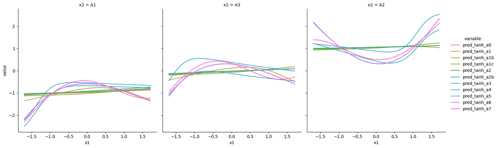

```python
sns.relplot(data = viz_grid_copy.melt(id_vars=['x1', 'x2']),
            x='x1', y='value', col='x2', hue='variable', kind='line')

plt.show()
```

However, the ADAM and LBFGS optimizer results are roughly more parabolic in shape. The trends are not identical but they are rather similar. This demonstrates why SGD is not recommended compared to the more advanced ADAM and LBFGS optimizers. The results are simply not as good for the optimizer settings we attempted in this example.

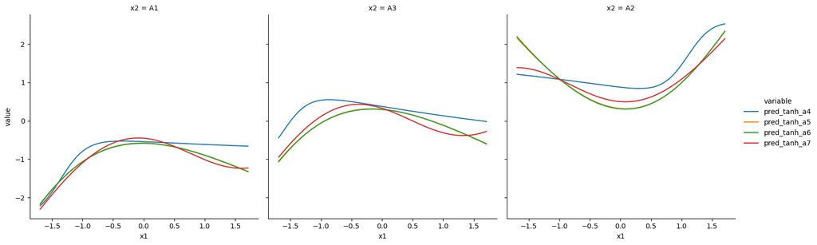

```python
sns.relplot(data = viz_grid_copy.loc[:, ['x1', 'x2', 'pred_tanh_a4', 'pred_tanh_a5', 'pred_tanh_a6', 'pred_tanh_a7']].melt(id_vars=['x1', 'x2']),
            x='x1', y='value', col='x2', hue='variable', kind='line')

plt.show()
```

**Why does this matter?**

The reason why these matter will be easier to see when we add more complexity to the our Neural Network.

### Add complexity - increase number of hidden units

The complexity of the neural network is controlled by the number of hidden units. More hidden units represents adding more features to a model. The more features the more coefficients that must be estimated.

Let's try a larger neural network with 7 hidden units. This model will therefore need to estimate the following number of coefficients.

```python
7 * (3 + 1) + 7 + 1
```

```
36
```

Let's continue to use the LBFGS optimizer since this is a "small" model.

```python
nnet_hidden7_tanh_a0 = MLPRegressor(activation='tanh',
                                    hidden_layer_sizes=7,
                                    solver='lbfgs', max_iter=5001, random_state=101,
                                    alpha=0.0001)
```

```python
nnet_hidden7_tanh_a0_wflow = Pipeline( steps=[('prepro', preprocess_transform),
                                              ('nnet', nnet_hidden7_tanh_a0)] )
```

```python
fit_nnet_hidden7_tanh_a0 = nnet_hidden7_tanh_a0_wflow.fit( x_inputs_df, df.y.to_numpy().ravel() )
```

There are more intercepts because there are more hidden units.

```python
fit_nnet_hidden7_tanh_a0.named_steps['nnet'].intercepts_
```

```
[array([ 1.21624385, -2.2895311 , -1.20759588, -1.34126637,  0.74729059,
         2.78183811, -0.43035064]),
 array([-2.3380412])]
```

There are more coefficients because there are more hidden units.

```python
fit_nnet_hidden7_tanh_a0.named_steps['nnet'].coefs_
```

```
[array([[-0.91527662,  0.03497036, -0.63158767,  1.11950256, -0.23091416,
         -1.15178244, -0.48460422],
        [ 2.48409714,  1.2486071 , -2.70411933, -0.49909093, -0.26788853,
         -4.25933135,  2.26925333],
        [ 2.3818172 , -0.32251533, -3.80054511,  1.02572115,  0.25918039,
         -2.3445284 , -1.13156968]]),
 array([[ 3.60375606],
        [ 3.53818646],
        [-4.39563599],
        [ 1.70245707],
        [-1.46060919],
        [ 1.73196837],
        [ 1.31245793]])]
```

The `.coefs_` attribute is a list. The zeroth element contains the HIDDEN UNIT coefficients. The zeroth element has 7 columns because there are 7 hidden units. There are 3 rows because there are 3 columns in the DESIGN MATRIX.

```python
fit_nnet_hidden7_tanh_a0.named_steps['nnet'].coefs_[0].shape
```

```
(3, 7)
```

The 1 element has 7 elements because there are 7 hidden units.

```python
fit_nnet_hidden7_tanh_a0.named_steps['nnet'].coefs_[1].shape
```

```
(7, 1)
```

Just fit one more time with a different seed.

```python
nnet_hidden7_tanh_a1 = MLPRegressor(activation='tanh',
                                    hidden_layer_sizes=7,
                                    solver='lbfgs', max_iter=5001, random_state=909,
                                    alpha=0.0001)
```

```python
nnet_hidden7_tanh_a1_wflow = Pipeline( steps=[('prepro', preprocess_transform),
                                              ('nnet', nnet_hidden7_tanh_a1)] )
```

```python
fit_nnet_hidden7_tanh_a1 = nnet_hidden7_tanh_a1_wflow.fit( x_inputs_df, df.y.to_numpy().ravel() )
```

As before, changing the random seed produces different estimates.

```python
fit_nnet_hidden7_tanh_a1.named_steps['nnet'].intercepts_
```

```
[array([-0.1742003 , -3.56006629, -2.90039558, -1.39295264, -2.05528446,
        -0.33044904, -3.55449657]),
 array([-1.62105184])]
```

```python
fit_nnet_hidden7_tanh_a0.named_steps['nnet'].intercepts_
```

```
[array([ 1.21624385, -2.2895311 , -1.20759588, -1.34126637,  0.74729059,
         2.78183811, -0.43035064]),
 array([-2.3380412])]
```

Compare the predictions from these two larger number of hidden unit neural networks.

```python
viz_copy_2 = viz_grid.copy()
```

```python
viz_copy_2['pred_tanh_7_0'] = fit_nnet_hidden7_tanh_a0.predict( viz_grid )
```

```python
viz_copy_2['pred_tanh_7_1'] = fit_nnet_hidden7_tanh_a1.predict( viz_grid )
```

The predictions from the two models are **very** similar!

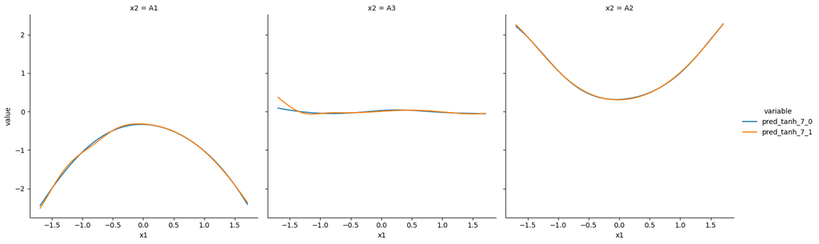

```python
sns.relplot(data = viz_copy_2.melt(id_vars=['x1', 'x2']),
            x='x1', y='value', col='x2', hue='variable', kind='line')

plt.show()
```

**Why does this matter?**

We have seen that fitting the models with different random seeds produces different coefficient estimates. These estimates are found by minimizing the **SSE plus the Ridge Penalty**. The random seed controlls the initial guess provided to the optimizer. The initial guess therefore impacts the estimates. But, even though the coefficients are different the final predictive trends **might** be similar. This is because the **hidden unit** coefficients **generate** the features and then the features are **weighted** in the output layer to produce the prediction. The hidden unit intercepts and coefficients therefore **work together** with the output layer intercept and coefficients.

This is important because we have used the regression coefficients to help interpret model behavior. We used this for linear models, logistic regression, and Poisson regression. The coefficients let us find important inputs. We **cannot** do that with Neural Networks. The coefficient or **weight** multiplying an input in the hidden layer **is not the only** coefficient associated with that input. There are **many more** in the hidden layer **and** the output layer. Therefore Neural Networks are **not easily** intepretable! Neural Networks are used to maximize predictive performance **at the expense** of understanding **how** the inputs influence those predictions.

You may find advanced approaches that attempt to rank inputs in Neural Networks. Those approaches are beyond the scope of this course, but a general advice of **the lack of interpretability** of Neural Networks is always important to keep in mind.

### Regularization - impact of `alpha`

The `alpha` parameter is the **regularization strength** that multiplies the RIDGE penalty. We have used a small value up to this point which means the intercepts and coefficients are estimated to minimize the SSE as much as possible. Small `alpha` values therefore allow for overfitting to the training set. Increasing `alpha` will **prevent** extreme coefficient estimates. Several of the previous models included some extremem estimates. The first LBFGS model had a double digit intercept and coefficient!

```python
fit_nnet_small_tanh_a5.named_steps['nnet'].intercepts_
```

```
[array([1.32536692, 1.01310166]), array([22.22390914])]
```

```python
fit_nnet_small_tanh_a5.named_steps['nnet'].coefs_
```

```
[array([[ 0.51286266,  0.06059662],
        [-2.26044476, -0.54600738],
        [ 0.01955185, -0.051979  ]]),
 array([[  7.29537138],
        [-37.98707437]])]
```

Extreme coefficients can be associated with overfitting. We learned previously that RIDGE regression guards against overfitting by penalizing large coefficient values. Neural Networks can also have the RIDGE penalty applied to prevent extreme coefficients.

Let's fit the 2-hidden unit Neural Network with LBFGS again but this time increase `alpha` to a very large value. The cell below initializes a Neural Network with `alpha=10000`. The random seed is set to `random_state=101` just like the first time `nnet_small_tanh_a5` was initialized. Thus, the only difference between the previous time this model was fit is the very large **regularization strength**

```python
nnet_small_tanh_a5_large_alpha = MLPRegressor(activation='tanh',
                                              hidden_layer_sizes=2,
                                              solver='lbfgs', max_iter=5001, random_state=101,
                                              alpha=10000)
```

```python
nnet_small_tanh_a5_large_alpha_wflow = Pipeline( steps=[('prepro', preprocess_transform),
                                                        ('nnet', nnet_small_tanh_a5_large_alpha)] )
```

```python
fit_nnet_small_tanh_a5_large_alpha = nnet_small_tanh_a5_large_alpha_wflow.fit( x_inputs_df, df.y.to_numpy().ravel() )
```

The intercepts for the `alpha=10000` model are given below.

```python
fit_nnet_small_tanh_a5_large_alpha.named_steps['nnet'].intercepts_
```

```
[array([-0.42100841,  0.85549564]), array([0.01527109])]
```

The coefficients are:

```python
fit_nnet_small_tanh_a5_large_alpha.named_steps['nnet'].coefs_
```

```
[array([[1.36164378e-07, 2.63932531e-06],
        [1.80355882e-06, 4.95289006e-07],
        [1.21364958e-06, 6.29758580e-07]]),
 array([[-2.01126184e-06],
        [-2.45525468e-06]])]
```

The values are difficult to read so let's round them. The hidden unit coefficients are essentially zero!

```python
np.round( fit_nnet_small_tanh_a5_large_alpha.named_steps['nnet'].coefs_[0], 1 )
```

```
array([[0., 0.],
       [0., 0.],
       [0., 0.]])
```

Likewise the output layer coefficients are essentially zero!

```python
np.round( fit_nnet_small_tanh_a5_large_alpha.named_steps['nnet'].coefs_[1], 1 )
```

```
array([[-0.],
       [-0.]])
```

The first time this model was fit with a very small `alpha` resulted in a very large output layer coefficient!

```python
np.round( fit_nnet_small_tanh_a5.named_steps['nnet'].coefs_[1], 1 )
```

```
array([[  7.3],
       [-38. ]])
```

Thus, large `alpha` has the **same** effect that we saw with RIDGE REGRESSION! Large `alpha` can force the coefficients very close to zero! The RIDGE PENALTY has effectively turned the neural network into model with ZERO TRENDS!

The same concept applies to a neural network with more hidden units. The cell below initializes the neural network with 7 hidden units. The random seed is the same as that used to initialize `nnet_hidden7_tanh_a0`.

```python
nnet_hidden7_tanh_large_alpha = MLPRegressor(activation='tanh',
                                             hidden_layer_sizes=7,
                                             solver='lbfgs', max_iter=5001, random_state=101,
                                             alpha=10000)
```

```python
nnet_hidden7_tanh_large_alpha_wflow = Pipeline( steps=[('prepro', preprocess_transform),
                                                       ('nnet', nnet_hidden7_tanh_large_alpha)] )
```

```python
fit_nnet_hidden7_tanh_large_alpha = nnet_hidden7_tanh_large_alpha_wflow.fit( x_inputs_df, df.y.to_numpy().ravel() )
```

The intercepts for the 7 hidden unit neural network with large `alpha` are:

```python
fit_nnet_hidden7_tanh_large_alpha.named_steps['nnet'].intercepts_
```

```
[array([ 0.0341613 , -0.69958694, -0.55675149, -0.47872025,  0.76494535,
         0.02793654,  0.13417419]),
 array([0.01526743])]
```

The coefficients for the 7 hidden unit neural network with large `alpha` are:

```python
fit_nnet_hidden7_tanh_large_alpha.named_steps['nnet'].coefs_
```

```
[array([[-4.24377204e-07, -6.57971864e-08, -3.91640273e-07,
         -4.97057636e-07,  1.77369871e-07,  3.30002634e-07,
         -1.09314660e-06],
        [ 1.82478483e-07,  2.15887495e-08,  2.52360166e-07,
          2.56107476e-07, -7.93397715e-08, -1.80198956e-07,
          9.40956374e-08],
        [ 1.61521137e-07, -8.05667525e-08,  4.93882866e-09,
          5.12048010e-08,  4.94390765e-08, -5.40998751e-08,
         -4.82825206e-08]]),
 array([[ 1.39759495e-07],
        [-8.69133742e-07],
        [-9.65742053e-08],
        [ 1.57856810e-07],
        [ 5.00291941e-07],
        [-9.13396483e-07],
        [ 7.65695019e-07]])]
```

Again, since these are hard to read let's display the rounded values. The hidden unit coefficients are:

```python
np.round( fit_nnet_hidden7_tanh_large_alpha.named_steps['nnet'].coefs_[0], 1 )
```

```
array([[-0., -0., -0., -0.,  0.,  0., -0.],
       [ 0.,  0.,  0.,  0., -0., -0.,  0.],
       [ 0., -0.,  0.,  0.,  0., -0., -0.]])
```

The output layer coefficients are:

```python
np.round( fit_nnet_hidden7_tanh_large_alpha.named_steps['nnet'].coefs_[1], 1 )
```

```
array([[ 0.],
       [-0.],
       [-0.],
       [ 0.],
       [ 0.],
       [-0.],
       [ 0.]])
```

The very large `alpha` has therefore turned the neural network into an INTERCEPT-ONLY model! The slopes multiplying the inputs in the hidden layer and the slopes multiplying the features in the output layer are all zero!

We can confirm this is the case by making predictions from the model with large `alpha`.

```python
viz_copy_2['pred_tanh_7_0_large_alpha'] = fit_nnet_hidden7_tanh_large_alpha.predict( viz_grid )
```

The green flat horizontal line are the predictions from a Neural Network! It's just that Neural Network had such a large **regularization strength** the coefficients were forced to be very close to zero and thus all trends were removed!

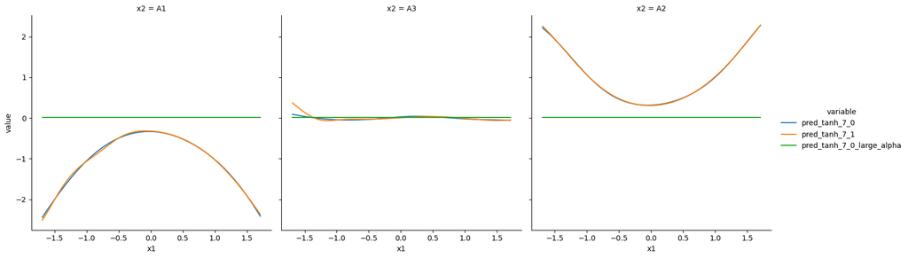

```python
sns.relplot(data = viz_copy_2.melt(id_vars=['x1', 'x2']),
            x='x1', y='value', col='x2', hue='variable', kind='line')

plt.show()
```

**Why does this matter?**

What this leads to is we have **TWO** ways to control complexity in Neural Networks. The basic approach is fewer hidden units (neurons) are simpler, less complex models because there are fewer features. Including more hidden units increases the number of features which increases the complexity. We do not know the approach number of hidden units to use and so we must **tune** the number of hidden units with cross-validation. An alternative approach is to use the regularization strength to control the complexity. You start with a relatively large number of hidden units and use the regularization strength (RIDGE PENALTY) to simplify the model. The regularization strength must be **tuned** via cross-validation.

The most flexible strategy is to tune **both** the number of hidden units **and** the regularization strength. I recommend using more unique values for regularization strength and just a few unique values for the number of hidden units if you want to use this approach.

**Important**: sklearn uses `alpha` as the regularization strength for classification neural networks as well! Thus, interpreting how regularization works for classification problems is the **same** as regression problems for neural networks. This is **not** the case for sklearn Ridge() and LogisticRegression() since the logistic regression model uses `C` to control regularization whereas Ridge() uses `alpha`.

### Tuning with Cross-Validation

This is a regression problem so we can use "regular" K-fold Cross-Validation.

```python
from sklearn.model_selection import KFold
```

The tuning will be managed by `GridSearchCV()`.

```python
from sklearn.model_selection import GridSearchCV
```

Use 5 fold cross-validation.

```python
my_cv = KFold(n_splits=5, random_state=101, shuffle=True)
```

Let's initialize the NEW workflow which allows us to TUNE `alpha`. The Neural Network model is initialized **but** `alpha` is **not** set. Let's use 7 hidden units to focus on the tuning of `alpha`.

```python
nnet_tanh_hidden7 = MLPRegressor(activation='tanh',
                                 hidden_layer_sizes=7,
                                 solver='lbfgs', max_iter=5001, random_state=101)
```

```python
nnet_tanh_hidden7_wflow = Pipeline( steps=[('prepro', preprocess_transform),
                                           ('nnet', nnet_tanh_hidden7) ] )
```

The tuning grid **must** follow the Pipeline naming convention of:

`<step name>__<parameter name>`

```python
nnet_hidden7_grid = {'nnet__alpha': [0.0001, 0.001, 0.01, 1, 10, 100, 1000]}
```

Initialize the grid search object. There are over 300 observations and we are using 5-fold CV, thus 20% of the data will be held out in each fold. The test sets will therefore have roughly 60 observations each. It is therefore safe to use R-squared as the regression performance metric.

```python
nnet_tanh_hidden7_search = GridSearchCV( nnet_tanh_hidden7_wflow, nnet_hidden7_grid, cv=my_cv, scoring='r2')
```

Execute the grid search. This runs relatively fast because the model is small and we only used 7 tuning parameter values.

```python
nnet_tanh_hidden7_search_results = nnet_tanh_hidden7_search.fit( x_inputs_df, df.y.to_numpy().ravel() )
```

The best tuning parameter:

```python
nnet_tanh_hidden7_search_results.best_params_
```

```
{'nnet__alpha': 0.01}
```

And the best score (R-squared) associated with that `alpha` value is:

```python
nnet_tanh_hidden7_search_results.best_score_
```

```
0.9746354939934291
```

The model is therefore quite good on this application.

Make predictions on our visualization grid:

```python
viz_copy_2['pred_tanh_7_tune'] = nnet_tanh_hidden7_search_results.predict( viz_grid )
```

The tuned neural network is predicting the parabolic trends associated with the data!

[figure not shown]

```python
sns.relplot(data = viz_copy_2, x='x1', y='pred_tanh_7_tune', col='x2', kind='line')

plt.show()
```

### Other activation functions

All of the previous neural networks used the same activation function. However, we could try other functions! Regression problems typically use hyperbolic tangent (tanh) or rectified linear units (Relu). The Relu is the default choice by `MLPRegressor()`. Binary classification problems tend to also use logistic functions. As long as the activation function is **not linear** (identity) then you are fitting a neural network. Otherwise, you are fitting a linear model!

How do you know which activation function to use? You don't! It's a modeling choice. Therefore, you need to use cross-validation to compare the performance of different activation functions!

Let's define a Pipeline to train and tune a 7-hidden unit Neural Network that uses the Relu activation function instead of hyperbolic tangent.

```python
nnet_relu_hidden7 = MLPRegressor(activation='relu',
                                 hidden_layer_sizes=7,
                                 solver='lbfgs', max_iter=5001, random_state=101)
```

```python
nnet_relu_hidden7_wflow = Pipeline( steps=[('prepro', preprocess_transform),
                                           ('nnet', nnet_relu_hidden7) ] )
```

Let's use the same `alpha` tuning grid.

```python
nnet_relu_hidden7_search = GridSearchCV( nnet_relu_hidden7_wflow, nnet_hidden7_grid, cv=my_cv, scoring='r2')
```

```python
nnet_relu_hidden7_search_results = nnet_tanh_hidden7_search.fit( x_inputs_df, df.y.to_numpy().ravel() )
```

The best tuning parameter value for the ReLu activation function is:

```python
nnet_relu_hidden7_search_results.best_params_
```

```
{'nnet__alpha': 0.01}
```

The best score for that tuning parameter is:

```python
nnet_relu_hidden7_search_results.best_score_
```

```
0.9746354939934291
```

```python
nnet_tanh_hidden7_search_results.best_score_
```

```
0.9746354939934291
```

```python
viz_copy_2['pred_relu_7_tune'] = nnet_relu_hidden7_search_results.predict( viz_grid )
```

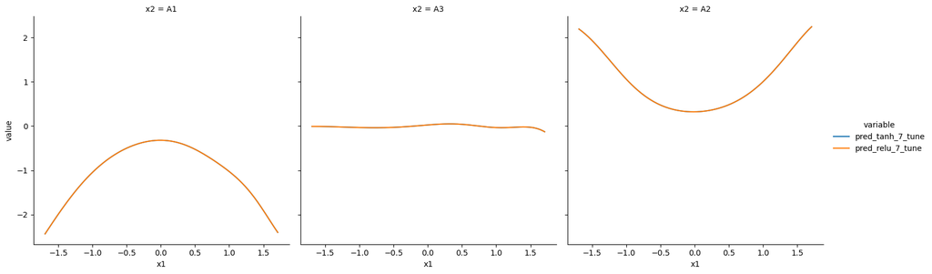

```python
sns.relplot(data = viz_copy_2.loc[:, ['x1', 'x2', 'pred_tanh_7_tune', 'pred_relu_7_tune']].melt(id_vars=['x1', 'x2']),
            x='x1', y='value', col='x2', hue='variable', kind='line')

plt.show()
```

In practice though, this may not be the case. So it can be useful to tune two different activation functions to see which yields the overall best results.

## Summary

This notebook demonstrated the impact of optimization arguments to show which arguments are essential. You should use either the ADAM or LBFGS solvers based on the number of unknown parameters that must be estimated. If there are less than 5000 parameters it is usually safe to use the LBFGS optimizer. This report demonstrated that if you do **not** set the random seed you may **never** be able to reproduce the estimates for the intercepts and coefficients. This is because the initial guess to the optimization algorithm **impacts** the final optimized estimates for Neural Networks!

Neural network complexity is controlled by the number of hidden units (neurons) and the regularization strength. You **must** use cross-validation to tune the complexity. This report focused on tuning the regularization strenght but you can tune both.